# Spatial Normal Model

```r
library(nimble, warn.conflicts = FALSE)
library(mcmcplots)
library(PICBayes)     # Sotuh Carolina adjacency matrix
library(spam)
library(tmap)         # Create a map
library(tigris)
library(RColorBrewer)
library(dplyr)
```

# Simulated Spatial Map

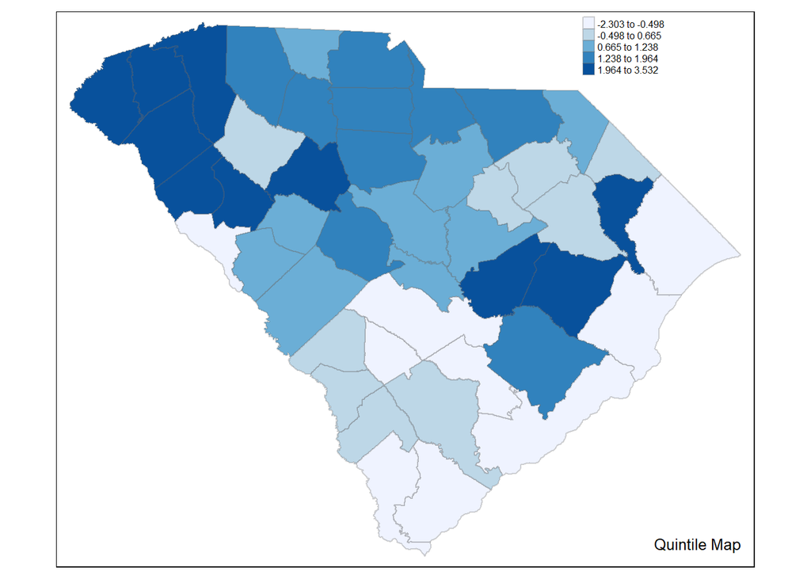

# Model Specification

$$Y_{ij}=\beta_0+\beta_1x_{1i}+\beta_2x_{2i}+s_i+e_i,
~~~i=1,\ldots,46;j=1,\ldots,n_i$$

- Let $Y_{ij}$ be the outcome of $j$-th patient ($j=1,\ldots,n_i$) in county $i$ $(i=1,\ldots,46)$
- *Intrinsic Conditional Auto-Regressive (ICAR)* models
  - $\boldsymbol{s}=(s_1,s_2,\ldots,s_i,\ldots,s_{46})^T_{46\times1}$, where $s_i$ is the spatial effect specific to county $i$
  - $s_i|s_j,j\ne i \sim \text{N}\left(\frac{\sum_{i\sim j}s_i}{d_{i}},\frac{1}{d_{i}\tau}\right)$
  - $d_i$ denotes the number of neighbor of county $i$
  - $i \sim j$ denotes the county $i$ and $j$ are neighbor
- Besag (1974) proved that the joint distribution of $\boldsymbol{s}$
  - $\boldsymbol{s}=(s_1,s_2,\ldots,s_i,\ldots,s_{46})^T \sim \text{N}(0,(\tau\boldsymbol{Q})^{-1})$
  - $\tau$ is a precision for Gaussian ICAR
  - $\boldsymbol{Q}=\boldsymbol{D}-\boldsymbol{A}$,
    - $\boldsymbol{D}$ is a $n\times n$ diagonal matrix, where the entries $\{i,i\}$ are number of neighbor of county $i$
    - $\boldsymbol{A}$ is a $n\times n$ adjacency matrix, where entries $\{i,i\}$ are $0$ and the off-diagonal elements are $1$ if counties $i$ and $j$ are neighbors and $0$ otherwise.
    - For the identifiability: $\sum_i\boldsymbol{s}_i=0$

# Toy Example

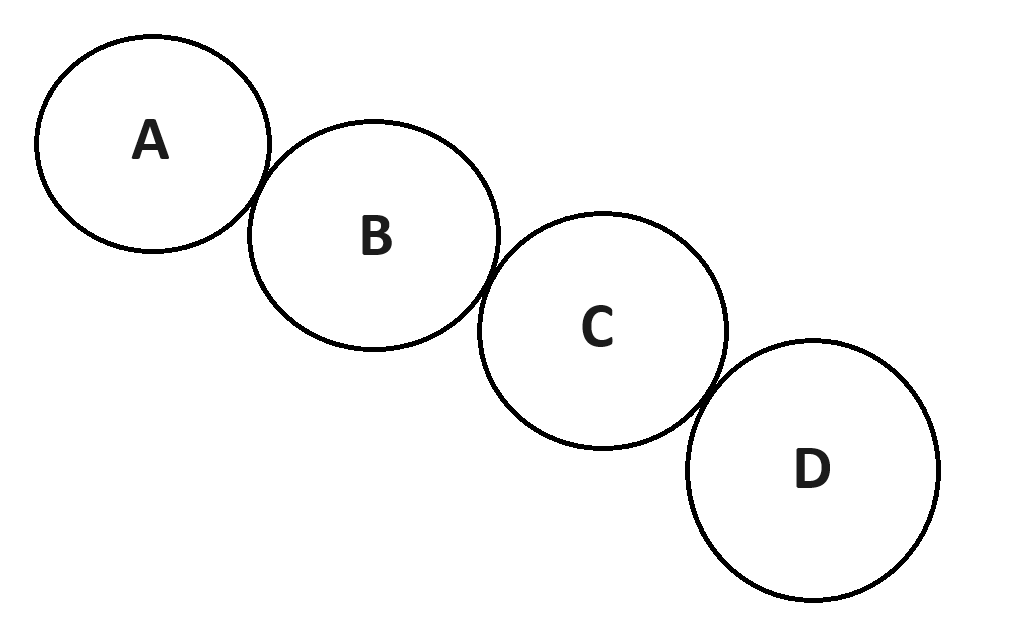

- $\boldsymbol{D}=\begin{bmatrix} 1 & 0 & 0 & 0 \\ 0 & 2 & 0 & 0 \\ 0 & 0 & 2 & 0 \\ 0&0&0&1\end{bmatrix}$
- $\boldsymbol{A}=\begin{bmatrix} 0 & 1 & 0 & 0 \\ 1 & 0 & 1 & 0 \\ 0 & 1 & 0 & 1 \\ 0&0&1&0\end{bmatrix}$
- $\boldsymbol{Q}=\boldsymbol{D}-\boldsymbol{A}$
- Adjacency vector$=(\underbrace{B}_A,\underbrace{A,C}_{B},\underbrace{B,D}_{C},\underbrace{C}_{D})$ (for the later use)

# Simulate Data

Simulate data from Equation:

$$Y_{ij}=\beta_0+\beta_1x_{1i}+\beta_2x_{2i}+s_i+e_i,
~~~i=1,\ldots,46;j=1,\ldots,n_i,$$

where - $(\beta_0,\beta_1,\beta_2)^T=(-0.25,0.65,-0.50)^T$;

- $\boldsymbol{s}\sim \text{ICAR}(\tau=0.5)$
- $e_{ij} \overset{iid}{\sim}\text{N}(0,4)$

```r
rm(list=ls())
set.seed(032210)
n<-46                                  # Number of county
nis<-sample(1:250,n,T)           # Number of patient in each county
id<-rep(1:n,nis)                 # County ID
N<-length(id)                    # Number of total patients

# Covariate
x1<-rnorm(N)
x2<-rbinom(N,1,0.5)
X<-cbind(1,x1,x2)
p<-ncol(X)

# Fixed Effect Parms
beta<-c(-0.25,0.65,-0.50)

# Spatial random effect
data(C)
A<-C                                            # Adjancency matrix
D<-apply(A,1,sum)                                 # No. neighbors
Q<-as.spam(diag(D))-as.spam(A) + diag(.0001,n)

varb<-truevarb<-2
taub<-truetaub<-1/varb                          # precision in ICAR
covb<-varb*solve(Q)
b<-c(mvtnorm::rmvnorm(1,sigma=covb))
trueb<-b-mean(b)                               # Center for identifiability

# Error variance
sigmae<-4

# Response
mu<-X%*%beta+rep(b-mean(b),nis)
y<-rnorm(N,mu,sqrt(sigmae))
```

# South Carolina (SC) Map

```r
dat<-data.frame(countyid=1:n,
                ymean=tapply(y,id,mean))

scfips<-c("45001","45003","45005","45007","45009",
          "45011","45013","45015","45017","45019","45021",
          "45023","45025","45027","45029","45031","45033",
          "45035","45037","45039","45041","45043","45045",
          "45047","45049","45051","45053","45055","45057",
          "45059","45061","45063","45065","45067","45069",
          "45071","45073","45075","45077","45079","45081",
          "45083","45085","45087","45089","45091")

dat$fips<-scfips
dat$GEOID<-as.character(dat$fips)
sc_counties_map <- counties(state = c('South Carolina'))
```

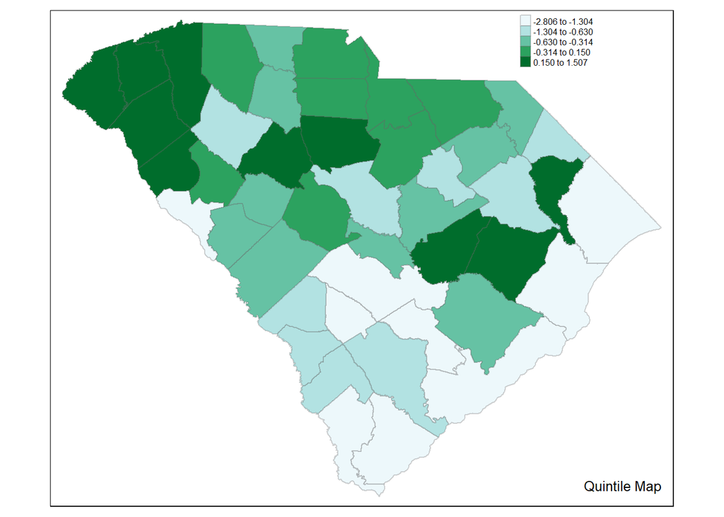

```r
sc_data <- left_join(sc_counties_map, dat, by = 'GEOID')
pal <- brewer.pal(5,"BuGn")  # specify the palette colors
tm_shape(sc_data)+
  tm_fill(c("ymean"), midpoint = c(NA), title = c(expression(paste(""))), palette = pal, style = "quantile")+
  tm_facets(free.scales = TRUE, nrow = 1)+
  tm_layout(title = "Quintile Map",
            title.snap.to.legend = TRUE,
            title.size = 0.8,
            title.position = c("right", "bottom"),
            legend.outside = FALSE,
            legend.position = c(0.75, 0.88),
            legend.text.size = 0.5,
            main.title.fontface = "bold",
            main.title.position = "center")+
  tm_borders(alpha = 0.3, lwd = 1)
```

# Nimble Code

- ICAR prior in Nimble
  - dcar_normal(adj,weights,num,tau,zero_mean)
    - adj: vector of indices of the adjacent locations (neighbors) of each spatial location
    - weights: vector of symmetric unnormalized weights associated with each pair of adjacent locations, of the same length as adj. If omitted, all weights are taken to be one.
    - num: vector giving the number of neighboring locations of each spatial location, with length equal to the total number of locations.
    - tau: scalar precision of the Gaussian CAR prior.
    - zero_mean: if 1, then during MCMC sampling, the mean of all locations is set to zero at each MCMC iteration (for identifiability)

```r
#--------#
# Nimble #
#--------#
# Adjacency matrix for spatial effect
tmp<-as.carAdjacency(A)
adj<-tmp$adj              # Adjacency vectors
weights<-tmp$weights      # Weights
num<-tmp$num              # Number of neighbors for each county
L<-length(adj)

#--------#
# Nimble #
#--------#
code <- nimbleCode({
  for(i in 1:N) {
    y[i] ~ dnorm(mu[i], tau = taue)
    mu[i]<-inprod(beta[1:p],X[i,1:p])+s[id[i]]
  }
  for (k in 1:p){beta[k]~dnorm(0,sd=100)}
  taub  ~ dgamma(0.0001,0.0001)               # ICAR precision
  varb <- 1/taub
  taue  ~ dgamma(0.0001,0.0001)               # error precision
  vare <- 1/taue
  s[1:n] ~ dcar_normal(adj=adj[1:L],weights=weights[1:L],
                       num=num[1:n],tau=taub,
                       zero_mean=1)           # ICAR prior
  # zero_mean=1: zero-mean constraint
})
constants <- list(N=N, n = n, p=p, L=L, id=id,adj=adj,weights=weights,num=num)
data <- list(y = y, X=X)
inits <- list(beta=rep(0,p),taub=1,taue=1, s=rnorm(n))
model <- nimbleModel(code, constants = constants, data = data, inits = inits)
```

```
## Defining model
```

```
## Building model
```

```
## Setting data and initial values
```

```
## Running calculate on model
##   [Note] Any error reports that follow may simply reflect missing values in model variables.
```

```
## Checking model sizes and dimensions
```

# Configure and Compile Model

```r
modelConf <- configureMCMC(model, print = TRUE)
```

```
## ===== Monitors =====
## thin = 1: beta, taub, taue
## ===== Samplers =====
## RW sampler (1)
##   - taub
## conjugate sampler (4)
##   - beta[]  (3 elements)
##   - taue
## CAR_normal sampler (1)
##   - s[1:46]
```

```r
modelConf$addMonitors("varb","vare","s")
```

```
## thin = 1: beta, s, taub, taue, varb, vare
```

```r
Cmodel <- compileNimble(model)
```

```
## Compiling
##   [Note] This may take a minute.
##   [Note] Use 'showCompilerOutput = TRUE' to see C++ compilation details.
```

# Compile MCMC Object

```r
modelMCMC <- buildMCMC(modelConf)
modelMCMC <- compileNimble(modelMCMC, project = model)
```

```
## Compiling
##   [Note] This may take a minute.
##   [Note] Use 'showCompilerOutput = TRUE' to see C++ compilation details.
```

# Run MCMC

```r
niter <- 10000     # Number of iterations
burn  <- niter/2   # Number of burn-ins
thin  <- 5         # Thinning interval
set.seed(1)
samples <- runMCMC(modelMCMC, niter = niter,nburnin = burn, nchains = 1,thin = thin,summary = TRUE)
```

```
## running chain 1...
```

```
## |-------------|-------------|-------------|-------------|
## |-------------------------------------------------------|
```

# Extract Sample

```r
samples$summary[c("beta[1]","beta[2]","beta[3]","taue","vare","varb","taub"),]  # estimate table
```

```
##               Mean     Median    St.Dev.  95%CI_low  95%CI_upp
## beta[1] -0.2653822 -0.2643928 0.04519706 -0.3541890 -0.1796528
## beta[2]  0.6528155  0.6537756 0.02600708  0.6008308  0.7044567
## beta[3] -0.4639060 -0.4642379 0.05415590 -0.5700481 -0.3609818
## taue     0.2489332  0.2490085 0.00481436  0.2398596  0.2581012
## vare     4.0186432  4.0159270 0.07776354  3.8744495  4.1691061
## varb     2.6864017  2.5812742 0.62358796  1.7012450  4.1448851
## taub     0.3918330  0.3874056 0.08878849  0.2412612  0.5878053
```

# MCMC Diagnostics

```r
# Check MCMC plot
out<-samples$samples[,c("beta[1]","beta[2]","beta[3]","taue","vare","varb","taub")]
mcmcplot(out,filename = "output")
```

# Observed and Expected Map

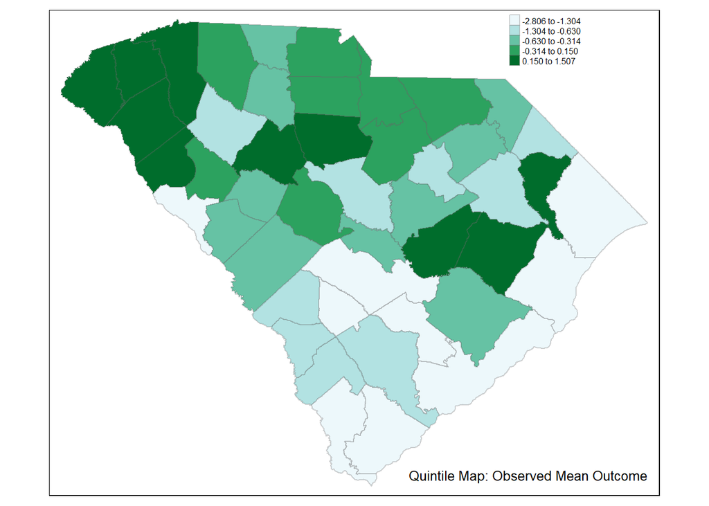

```r
dat<-data.frame(countyid=1:n,
                ymean=tapply(y,id,mean))
ms<-apply(samples$samples[,4:49],2,mean) # Posterior spatial effects
dat$ms<-ms

scfips<-c("45001","45003","45005","45007","45009",
          "45011","45013","45015","45017","45019","45021",
          "45023","45025","45027","45029","45031","45033",
          "45035","45037","45039","45041","45043","45045",
          "45047","45049","45051","45053","45055","45057",
          "45059","45061","45063","45065","45067","45069",
          "45071","45073","45075","45077","45079","45081",
          "45083","45085","45087","45089","45091")

dat$fips<-scfips
dat$GEOID<-as.character(dat$fips)
sc_counties_map <- counties(state = c('South Carolina'))
sc_data <- left_join(sc_counties_map, dat, by = 'GEOID')
pal <- brewer.pal(5,"BuGn")  # specify the palette colors

tm_shape(sc_data)+
  tm_fill(c("ymean"), midpoint = c(NA), title = c(expression(paste(""))), palette = pal, style = "quantile")+
  tm_facets(free.scales = TRUE, nrow = 1)+
  tm_layout(title = "Quintile Map: Observed Mean Outcome",
            title.snap.to.legend = TRUE,
            title.size = 0.8,
            title.position = c("right", "bottom"),
            legend.outside = FALSE,
            legend.position = c(0.75, 0.88),
            legend.text.size = 0.5,
            main.title.fontface = "bold",
            main.title.position = "center")+
  tm_borders(alpha = 0.3, lwd = 1)
```

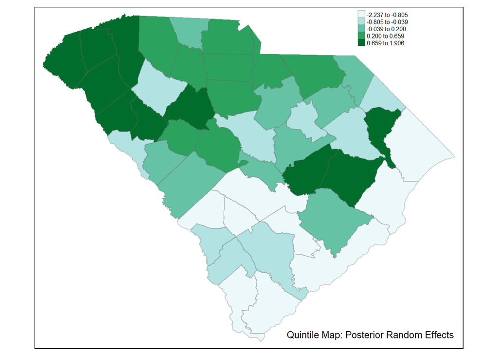

```r
tm_shape(sc_data)+
  tm_fill(c("ms"), midpoint = c(NA), title = c(expression(paste(""))), palette = pal, style = "quantile")+
  tm_facets(free.scales = TRUE, nrow = 1)+
  tm_layout(title = "Quintile Map: Posterior Random Effects",
            title.snap.to.legend = TRUE,
            title.size = 0.8,
            title.position = c("right", "bottom"),
            legend.outside = FALSE,
            legend.position = c(0.75, 0.88),
            legend.text.size = 0.5,
            main.title.fontface = "bold",
            main.title.position = "center")+
  tm_borders(alpha = 0.3, lwd = 1)
```